# MD005 - Sistemes Basats en el Coneixement

## Tercera Entrega: Models de Regressió

**Alumne:** Gerard Pascual Fontanilles  
**Professora:** Jordina Torrents  
**Data d'entrega:** 30 de gener de 2026

#### Informació sobre el conjunt de dades

Per fer aquest treball he tornat a utilitzar el conjunt de dades de pokemons. Extret de: https://www.kaggle.com/datasets/hamzacyberpatcher/data-of-1010-pokemons

Tornem a repassar el conjunt de dades: conté informació sobre 1025 pokemons diferents, incloent-hi les seves estadístiques bàsiques, tipus, generació i si evolucionen d'algun altre pokemon.

Les característiques principals del conjunt de dades són:

- Pokemon's id
- Pokemon's name
- Pokemon's rank (whether it is legendary, mythical, baby or an ordinary pokemon)
- Pokemon's generation
- The pokemon from which this pokemon evolved from
- It's primary and secondary type as type1 and type2
- It's base stats
- It's height (decimetres) and weight (hectograms)
- It's abilities (Note: if a pokemon has multiple abilities such as overgrow and chlorophyll than they are separated by a space and if there is a space in the name of the ability it has been replaced by a hyphen for example a pokemon with abilities blaze and solar power it is given as blaze solar-power)
- A little description of the pokemon in english (description of pokemons from 1009 is marked as "Not Available").

### Imports necessaris

```python
# --- 1. LLIBRERIES ESTÀNDARD I MANIPULACIÓ DE DADES ---
import pandas as pd
import numpy as np
import scipy.stats as stats
from scipy.stats import randint
import warnings

# --- 2. VISUALITZACIÓ GRÀFICA ---
import matplotlib.pyplot as plt
import seaborn as sns

# --- 3. SCIKIT-LEARN: PREPROCESSAMENT I PIPELINES ---
from sklearn.preprocessing import StandardScaler, OneHotEncoder
from sklearn.compose import ColumnTransformer
from sklearn.pipeline import Pipeline

# --- 4. SCIKIT-LEARN: MODELS (Regressió i Classificació) ---
from sklearn.linear_model import Ridge
from sklearn.ensemble import RandomForestRegressor, RandomForestClassifier

# --- 5. SCIKIT-LEARN: SELECCIÓ DE MODELS I OPTIMITZACIÓ ---
from sklearn.model_selection import train_test_split
from sklearn.experimental import enable_halving_search_cv  # Necessari per activar Halving
from sklearn.model_selection import GridSearchCV, RandomizedSearchCV, HalvingRandomSearchCV

# --- 6. SCIKIT-LEARN: MÈTRIQUES I EXCEPCIONS ---
from sklearn.metrics import (
    mean_squared_error, mean_absolute_error, r2_score,  # Mètriques Regressió
    accuracy_score, confusion_matrix, classification_report # Mètriques Classificació
)
from sklearn.exceptions import UndefinedMetricWarning
```

### Introducció: Canvi d'Enfocament

Encara que utilitzem el mateix conjunt de dades que en l'entrega anterior, l'objectiu d'aquesta pràctica és conceptualment diferent.

- **En la Classificació:** L'objectiu era la **discriminació**. Buscàvem separar els Pokémon en categories discretes (*Llegendari vs. Ordinari*). Ens fixàvem en la separabilitat de les classes i en traçar fronteres de decisió.
- **En la Regressió (Aquesta):** L'objectiu és la **predicció numèrica**. Ara busquem estimar un valor continu (per exemple, predir l'estadística de *Velocitat* o l'*Atac* basant-nos en la resta de característiques).

Per tant, l'anàlisi de dades canvia:

1. **Correlació vs. Separació:** Ja no busquem variables que separin grups, sinó variables que tinguin una **correlació lineal** o directa amb el nostre objectiu numèric (ex: si augmenta el pes, disminueix la velocitat?).
2. **Sensibilitat al Soroll:** En classificació, un outlier extrem podia ser fàcil de classificar. En regressió, un valor extrem pot desviar completament la línia de predicció i disparar l'error quadràtic mitjà (MSE), per la qual cosa la gestió d'outliers serà més crítica.

### Neteja i Preparació de Dades

Partim del coneixement adquirit en l'anàlisi anterior, però adaptem la neteja per maximitzar la capacitat predictiva numèrica:

1. **Dades Nul·les (`type2`):** Sabem que la columna `type2` conté molts valors nuls. En lloc d'eliminar aquestes files, imputarem el valor `'None'`. Això és important perquè, en regressió, el fet de ser un Pokémon "pur" (un sol tipus) pot tenir una correlació amb la distribució de les seves estadístiques.
2. **Transformació d'Evolucions (`evolves_from` -> `is_base`):**
- La columna `evolves_from` original conté text (noms de Pokémon), la qual cosa genera un soroll excessiu (massa categories úniques).
- No obstant això, **l'estat evolutiu és el predictor més fort de les estadístiques** (un Pokémon evolucionat és quasi sempre més fort que la seva base).
- Crearem, una altra vegada, una nova variable numèrica `is_base` (1 si no evoluciona de ningú, 0 si és una evolució) i eliminarem la columna de text original. Així conservem el senyal matemàtic sense el soroll del text.
3. **Eliminació de Soroll:**
- Eliminarem identificadors com `id`, `name`, `desc` i `abilities`. Aquestes variables no tenen una relació lineal directa amb les estadístiques numèriques i complicarien innecessàriament el model.

```python
df = pd.read_csv('pokemons.csv')
```

```python
df.info()
```

```
<class 'pandas.core.frame.DataFrame'>
RangeIndex: 1025 entries, 0 to 1024
Data columns (total 18 columns):
 #   Column        Non-Null Count  Dtype
---  ------        --------------  -----
 0   id            1025 non-null   int64
 1   name          1025 non-null   object
 2   rank          1025 non-null   object
 3   generation    1025 non-null   object
 4   evolves_from  1025 non-null   object
 5   type1         1025 non-null   object
 6   type2         526 non-null    object
 7   hp            1025 non-null   int64
 8   atk           1025 non-null   int64
 9   def           1025 non-null   int64
 10  spatk         1025 non-null   int64
 11  spdef         1025 non-null   int64
 12  speed         1025 non-null   int64
 13  total         1025 non-null   int64
 14  height        1025 non-null   int64
 15  weight        1025 non-null   int64
 16  abilities     1025 non-null   object
 17  desc          1025 non-null   object
dtypes: int64(10), object(8)
memory usage: 144.3+ KB
```

```python
nuls = df.isnull().sum()
print(nuls[nuls > 0])
```

```
type2    499
dtype: int64
```

```python
if 'type2' in df.columns:
    df['type2'] = df['type2'].fillna('None')
```

```python
df['is_base'] = df['evolves_from'].apply(lambda x: 1 if x == 'nothing' else 0)
print(f"{df['is_base'].value_counts()}")
```

```
is_base
1    541
0    484
Name: count, dtype: int64
```

```python
cols_to_drop = ['id', 'name', 'desc', 'abilities', 'evolves_from']

existing_drop = [c for c in cols_to_drop if c in df.columns]
df.drop(columns=existing_drop, inplace=True)
print(f"Columnes eliminades: {existing_drop}")
```

```
Columnes eliminades: ['id', 'name', 'desc', 'abilities', 'evolves_from']
```

```python
duplicats = df.duplicated().sum()
if duplicats > 0:
    df.drop_duplicates(inplace=True)
    print(f"S'han eliminat {duplicats} files duplicades.")
else:
    print("No hi ha files duplicades.")
```

```
No hi ha files duplicades.
```

```python
df.head()
```

|  | rank | generation | type1 | type2 | hp | atk | def | spatk | spdef | speed | total | height | weight | is_base |
| --- | --- | --- | --- | --- | --- | --- | --- | --- | --- | --- | --- | --- | --- | --- |
| 0 | ordinary | generation-i | grass | poison | 45 | 49 | 49 | 65 | 65 | 45 | 318 | 7 | 69 | 1 |
| 1 | ordinary | generation-i | grass | poison | 60 | 62 | 63 | 80 | 80 | 60 | 405 | 10 | 130 | 0 |
| 2 | ordinary | generation-i | grass | poison | 80 | 82 | 83 | 100 | 100 | 80 | 525 | 20 | 1000 | 0 |
| 3 | ordinary | generation-i | fire | None | 39 | 52 | 43 | 60 | 50 | 65 | 309 | 6 | 85 | 1 |
| 4 | ordinary | generation-i | fire | None | 58 | 64 | 58 | 80 | 65 | 80 | 405 | 11 | 190 | 0 |

```python
df.info()
```

```
<class 'pandas.core.frame.DataFrame'>
RangeIndex: 1025 entries, 0 to 1024
Data columns (total 14 columns):
 #   Column      Non-Null Count  Dtype
---  ------      --------------  -----
 0   rank        1025 non-null   object
 1   generation  1025 non-null   object
 2   type1       1025 non-null   object
 3   type2       1025 non-null   object
 4   hp          1025 non-null   int64
 5   atk         1025 non-null   int64
 6   def         1025 non-null   int64
 7   spatk       1025 non-null   int64
 8   spdef       1025 non-null   int64
 9   speed       1025 non-null   int64
 10  total       1025 non-null   int64
 11  height      1025 non-null   int64
 12  weight      1025 non-null   int64
 13  is_base     1025 non-null   int64
dtypes: int64(10), object(4)
memory usage: 112.2+ KB
```

### Anàlisi Exploratòria de Dades (EDA): Enfocament per a Regressió

Tot i que treballem amb el mateix dataset que en l'entrega anterior, l'objectiu matemàtic ha canviat radicalment, la qual cosa ens obliga a interrogar les dades d'una manera diferent (tornem a posar un exemple més clar):

- **En Classificació (Entrega Anterior):** Buscàvem **Discriminació i Separabilitat**.
  - *Pregunta:* "És l'Atac dels Llegendaris significativament diferent del dels Ordinaris?"
  - *Eina:* Boxplots i gràfics de barres per veure si les mitjanes estaven allunyades.
- **En Regressió (Aquesta Entrega):** Busquem **Correlació i Linealitat**.
  - *Pregunta:* "Quan augmenta el Pes d'un Pokémon, quant augmenta exactament el seu Atac?"
  - *Eina:* Scatterplots i Correlació de Pearson. Ja no ens importa separar grups, sinó modelar la tendència contínua de les dades.

Per validar si podem aplicar un model de Regressió Lineal amb garanties, executarem l'anàlisi en tres fases seqüencials:

1. **Visió Global (Mapa de Calor):**
- Calcularem la matriu de correlació per identificar quines variables tenen una relació forta amb el nostre objectiu (*Target*) i, molt important, vigilar la **Multicolinealitat**.
  - Si dues variables predictores (ex: `Defense` i `Sp. Def`) tenen una correlació excessiva ($>0.85$), aporten informació redundant que pot desestabilitzar els coeficients del model.
2. **Comprovació de Linealitat (Pairplots):**
- Generarem gràfics de dispersió (*scatter plots*) creuats.
- Busquem "núvols" de punts que segueixin una tendència recta (ascendent o descendent). Si veiem formes de "U" o núvols totalment rodons, sabrem que la regressió lineal tindrà dificultats.
3. **Validació de Normalitat (Histogrames + QQ-Plots):**
- Aquesta és la prova més rigorosa. Els models de regressió assumeixen que les variables (o els seus errors) segueixen una **Distribució Normal** (Campana de Gauss).
- Utilitzarem **QQ-Plots** al costat dels Histogrames. Si els punts del QQ-Plot es desvien de la línia diagonal, sabrem que tenim problemes d'asimetria (*Skewness*) o *outliers*, i haurem d'aplicar transformacions matemàtiques (com el logaritme) per corregir-ho.

```python
numeric_cols = ['hp', 'atk', 'def', 'spatk', 'spdef', 'speed', 'height', 'weight']
df_num = df[numeric_cols]
```

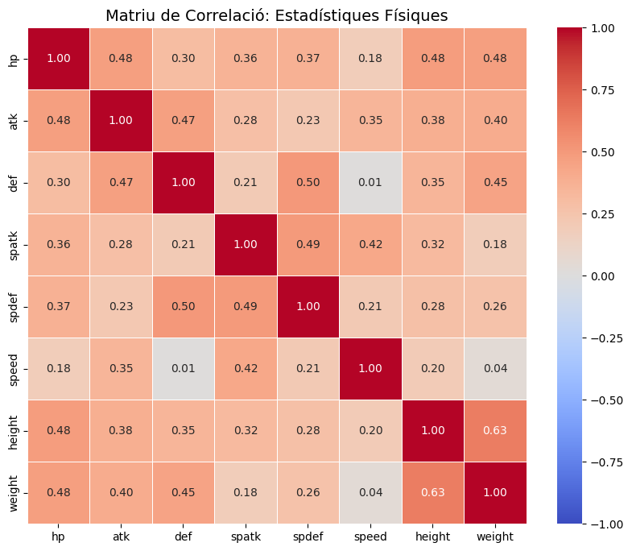

```python
plt.figure(figsize=(10, 8))
correlation_matrix = df_num.corr()

sns.heatmap(correlation_matrix,
            annot=True,
            fmt=".2f",
            cmap='coolwarm',
            vmin=-1, vmax=1,
            linewidths=0.5)

plt.title('Matriu de Correlació: Estadístiques Físiques', fontsize=14)
plt.show()
```

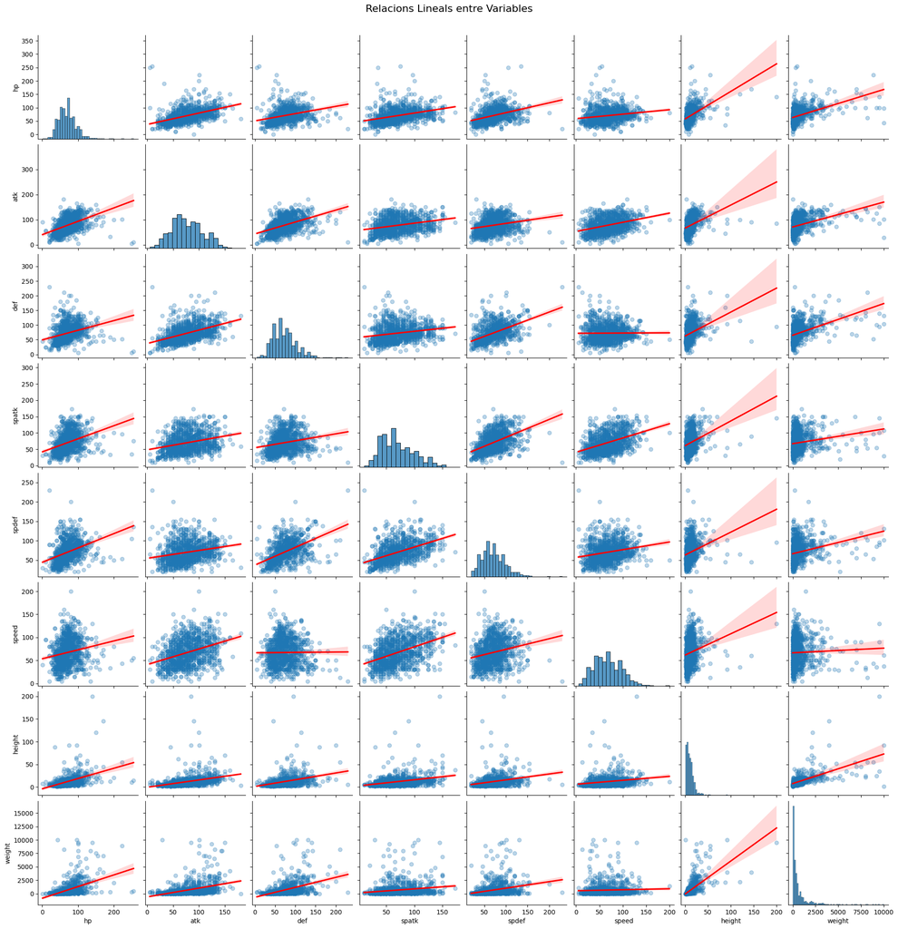

```python
sns.pairplot(df_num,
             kind='reg',
             plot_kws={'line_kws':{'color':'red'}, 'scatter_kws': {'alpha': 0.3}})
plt.suptitle("Relacions Lineals entre Variables", y=1.02, fontsize=16)
plt.show()
```

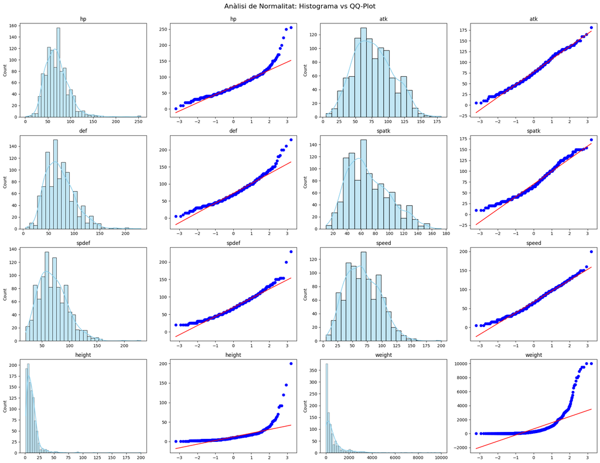

```python
plt.figure(figsize=(20, 15))

for i, col in enumerate(numeric_cols):
    plt.subplot(4, 4, 2*i + 1)
    sns.histplot(df[col], kde=True, color='skyblue')
    plt.title(f'{col}')
    plt.xlabel('')

    plt.subplot(4, 4, 2*i + 2)
    stats.probplot(df[col], dist="norm", plot=plt)
    plt.title(f'{col}')
    plt.xlabel('')
    plt.ylabel('')

plt.tight_layout()
plt.suptitle("Anàlisi de Normalitat: Histograma vs QQ-Plot", y=1.02, fontsize=16)
plt.show()
```

L'anàlisi conjunta visual (**Pairplots**) i estadística (**QQ-Plots**) ens permet extreure conclusions robustes sobre la naturalesa de les dades:

### Justificació de la Transformació Logarítmica

Donats els resultats anteriors, hem decidit aplicar una transformació matemàtica (`np.log1p`) exclusivament a les variables **Pes (`weight`)** i **Alçada (`height`)**.

**Per què fem això?**

```python
df['log_height'] = np.log1p(df['height'])
df['log_weight'] = np.log1p(df['weight'])
```

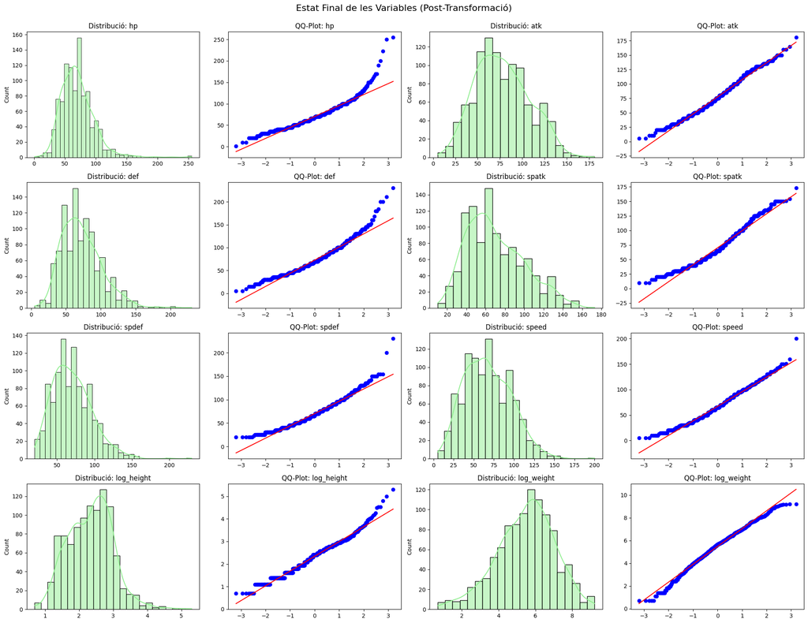

```python
final_numeric_cols = ['hp', 'atk', 'def', 'spatk', 'spdef', 'speed', 'log_height', 'log_weight']
df_num_final = df[final_numeric_cols]
plt.figure(figsize=(20, 15))

for i, col in enumerate(final_numeric_cols):
    plt.subplot(4, 4, 2*i + 1)
    sns.histplot(df[col], kde=True, color='lightgreen')
    plt.title(f'Distribució: {col}')
    plt.xlabel('')

    plt.subplot(4, 4, 2*i + 2)
    stats.probplot(df[col], dist="norm", plot=plt)
    plt.title(f'QQ-Plot: {col}')
    plt.xlabel('')
    plt.ylabel('')

plt.tight_layout()
plt.suptitle("Estat Final de les Variables (Post-Transformació)", y=1.02, fontsize=16)
plt.show()
```

Els gràfics finals confirmen que l'estratègia de transformació ha estat un èxit. La comparativa visual és concloent:

1. **Correcció de la Distribució (`log_height` i `log_weight`):**
- Si observem els nous **QQ-Plots**, veiem que els punts blaus s'alineen ara gairebé perfectament amb la línia vermella de referència.
- La curvatura extrema que teníem originalment ha desaparegut. Això indica que hem eliminat el biaix positiu excessiu i hem aconseguit una distribució molt propera a la **Normalitat**.
2. **Histogrames Centrats:**
- Els histogrames ja no mostren una única barra aixafada a l'esquerra. Ara tenen una forma de campana (Gaussiana) molt més definida, amb les dades centrades i les cues simètriques.

> Amb aquestes noves variables transformades, hem satisfet els requisits estadístics per a la **Regressió Lineal**. Hem neutralitzat l'efecte nociu dels *outliers* gegants, permetent que el model pugui aprendre patrons generals de manera robusta sense ser distorsionat pels valors extrems.

Un cop aplicades les transformacions logarítmiques a l'Alçada i al Pes, tornem a generar els gràfics de dispersió (**Pairplots**) per verificar l'impacte en la linealitat.

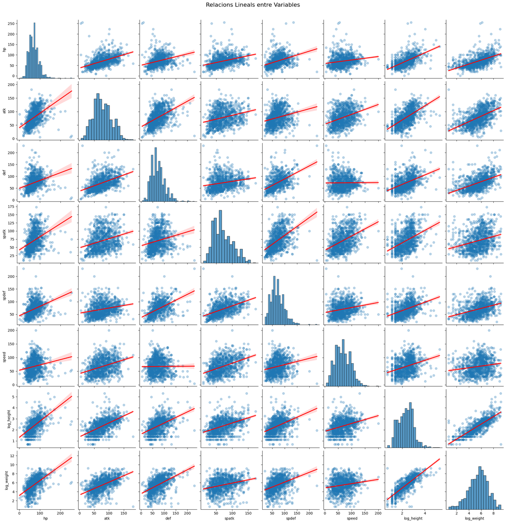

```python
sns.pairplot(df_num_final,
             kind='reg',
             plot_kws={'line_kws':{'color':'red'}, 'scatter_kws': {'alpha': 0.3}})
plt.suptitle("Relacions Lineals entre Variables", y=1.02, fontsize=16)
plt.show()
```

- Si observem les files de `log_height` i `log_weight`, veiem que els punts ja no estan comprimits contra els eixos. Ara formen "núvols" de punts ovalats i centrats.
- **Millora de la Linealitat amb l'Objectiu:** La relació entre `log_weight` i l'Atac (`atk`) és ara molt més clara i rectilínia. La línia de regressió vermella travessa el centre de la distribució, indicant que la correlació és constant en tot el rang de dades.
> - Les variables transformades són predictors molt més fiables per a un model lineal que les originals.